# Major Project - Quantitative

Guidelines for Major Projectin Quantitive Data Handling

Deadline: September 1st 2025

Length: 9 pages maximum, not including figures and tables

Contents

1. Describe your research project in less than 100 words *(20 marks)*
2. Give an except of your data (first ten rows) *(10 marks)*
3. Produce a table describing each column on the data *(10 marks)*
4. Produce a summary of your data using a function like `summary()`, `str()`, `dplyr::glimpse()`, or `skimr::skim()` *(10 marks)*
5. Produce some summary statistics using `group_by()` and `summarise()` *(10 marks)*
6. Produce some confidence intervals *(10 marks)*
7. Produce some hypothesis reports *(10 marks)*
8. Produce some data visualisations *(10 marks)*
9. Summarise your report in less than 100 words *(10 marks)*

### This could be useful

It is possible to create the entire report all within R, integrating all the data, tables, and graphics without having to cut, paste, or insert anything. The utility that does this is called [quatro](https://quarto.org/docs/get-started/hello/rstudio.html). In fact, this document is written in `quarto` and you can see the code that produced it at [this link](https://github.com/eugene100hickey/ATU-2025/blob/main/major-project.qmd).

The tables here were produced using the [gt](https://gt.rstudio.com/) package. It’s a bit like `ggplot2` for tables. Like `quarto`, it takes a bit of getting used to, but it makes very nice data tables.

The easiest way to make a pdf from this is to make a html file first and then print to pdf (quarto can do pdf’s directly, but then you need Latex installed).

## Example Report

Below is an example report using our `palmerpenguins::penguins` dataset.

### 1. Data Description

Data were collected and made available by [Dr. Kristen Gorman](https://www.uaf.edu/cfos/people/faculty/detail/kristen-gorman.php) and the [Palmer Station, Antarctica LTER](https://pallter.marine.rutgers.edu/), a member of the [Long Term Ecological Research Network](https://lternet.edu/). It includes Size measurements for adult foraging Adélie, Chinstrap, and Gentoo penguins observed on islands in the Palmer Archipelago near Palmer Station, Antarctica.

### 2. Data Excerpt

```r
library(tidyverse)
library(palmerpenguins)
library(gt)


penguins |>
  slice_sample(n = 8) |>
  drop_na() |>
  gt::gt() |>
  gt::cols_label(bill_length_mm = html("Bill Length<br>(mm)"),
                 bill_depth_mm = html("Bill Depth<br>(mm)"),
                 flipper_length_mm = html("Flipper Length<br>(mm)"),
                 body_mass_g = html("Weight<br>(g)"))
```

| species | island | Bill Length (mm) | Bill Depth (mm) | Flipper Length (mm) | Weight (g) | sex | year |
| --- | --- | --- | --- | --- | --- | --- | --- |
| Gentoo | Biscoe | 44.0 | 13.6 | 208 | 4350 | female | 2008 |
| Gentoo | Biscoe | 48.2 | 14.3 | 210 | 4600 | female | 2007 |
| Adelie | Dream | 35.6 | 17.5 | 191 | 3175 | female | 2009 |
| Chinstrap | Dream | 51.0 | 18.8 | 203 | 4100 | male | 2008 |
| Gentoo | Biscoe | 46.8 | 16.1 | 215 | 5500 | male | 2009 |
| Adelie | Biscoe | 37.6 | 17.0 | 185 | 3600 | female | 2008 |
| Adelie | Biscoe | 42.7 | 18.3 | 196 | 4075 | male | 2009 |
| Gentoo | Biscoe | 46.5 | 14.8 | 217 | 5200 | female | 2008 |

### 3. Data Codebook

| column | description |
| --- | --- |
| species | a factor denoting penguin species (Adélie, Chinstrap and Gentoo) |
| island | a factor denoting island in Palmer Archipelago, Antarctica (Biscoe, Dream or Torgersen) |
| bill_length_mm | a number denoting bill length (millimeters) |
| bill_depth_mm | a number denoting bill depth (millimeters) |
| flipper_length_mm | an integer denoting flipper length (millimeters) |
| body_mass_g | an integer denoting body mass (grams) |
| sex | a factor denoting penguin sex (female, male) |
| year | an integer denoting the study year (2007, 2008, or 2009) |

### 4. Data Summary

```r
penguins |> skimr::skim()
```

Data summary

| Name | penguins |
| --- | --- |
| Number of rows | 344 |
| Number of columns | 8 |
| _______________________ |  |
| Column type frequency: |  |
| factor | 3 |
| numeric | 5 |
| ________________________ |  |
| Group variables | None |

**Variable type: factor**

| skim_variable | n_missing | complete_rate | ordered | n_unique | top_counts |
| --- | --- | --- | --- | --- | --- |
| species | 0 | 1.00 | FALSE | 3 | Ade: 152, Gen: 124, Chi: 68 |
| island | 0 | 1.00 | FALSE | 3 | Bis: 168, Dre: 124, Tor: 52 |
| sex | 11 | 0.97 | FALSE | 2 | mal: 168, fem: 165 |

**Variable type: numeric**

| skim_variable | n_missing | complete_rate | mean | sd | p0 | p25 | p50 | p75 | p100 | hist |
| --- | --- | --- | --- | --- | --- | --- | --- | --- | --- | --- |
| bill_length_mm | 2 | 0.99 | 43.92 | 5.46 | 32.1 | 39.23 | 44.45 | 48.5 | 59.6 | ▃▇▇▆▁ |
| bill_depth_mm | 2 | 0.99 | 17.15 | 1.97 | 13.1 | 15.60 | 17.30 | 18.7 | 21.5 | ▅▅▇▇▂ |
| flipper_length_mm | 2 | 0.99 | 200.92 | 14.06 | 172.0 | 190.00 | 197.00 | 213.0 | 231.0 | ▂▇▃▅▂ |
| body_mass_g | 2 | 0.99 | 4201.75 | 801.95 | 2700.0 | 3550.00 | 4050.00 | 4750.0 | 6300.0 | ▃▇▆▃▂ |
| year | 0 | 1.00 | 2008.03 | 0.82 | 2007.0 | 2007.00 | 2008.00 | 2009.0 | 2009.0 | ▇▁▇▁▇ |

### 5. Summary Statistics

```r
penguins |>
  group_by(island, sex, species) |>
  summarise(
    mean_flipper_length_mm = mean(flipper_length_mm, na.rm = T) |> signif(3),
    mean_body_mass_g = mean(body_mass_g, na.rm = T) |> signif(3),
    mean_bill_length_mm = mean(bill_length_mm, na.rm = T) |> signif(3),
    mean_bill_depth_mm = mean(bill_depth_mm, na.rm = T) |> signif(3)
  ) |>
  drop_na() |>
  ungroup() |>
  gt::gt(rowname_col = "species",
         groupname_col = "sex") |>
  gt::cols_label(
    mean_bill_length_mm = html("Mean Bill Length<br>(mm)"),
    mean_bill_depth_mm = html("Mean Bill Depth<br>(mm)"),
    mean_flipper_length_mm = html("Mean Flipper Length<br>(mm)"),
    mean_body_mass_g = html("Mean Weight<br>(g)")
  ) |>
  tab_options(row_group.as_column = TRUE)
```

|  |  | island | Mean Flipper Length (mm) | Mean Weight (g) | Mean Bill Length (mm) | Mean Bill Depth (mm) |
| --- | --- | --- | --- | --- | --- | --- |
| female | Adelie | Biscoe | 187 | 3370 | 37.4 | 17.7 |
|  | Gentoo | Biscoe | 213 | 4680 | 45.6 | 14.2 |
|  | Adelie | Dream | 188 | 3340 | 36.9 | 17.6 |
|  | Chinstrap | Dream | 192 | 3530 | 46.6 | 17.6 |
|  | Adelie | Torgersen | 188 | 3400 | 37.6 | 17.6 |
| male | Adelie | Biscoe | 190 | 4050 | 40.6 | 19.0 |
|  | Gentoo | Biscoe | 222 | 5480 | 49.5 | 15.7 |
|  | Adelie | Dream | 192 | 4050 | 40.1 | 18.8 |
|  | Chinstrap | Dream | 200 | 3940 | 51.1 | 19.3 |
|  | Adelie | Torgersen | 195 | 4030 | 40.6 | 19.4 |

### 6. Confidence Intervals for Flipper Length and Body Weight

```r
penguins |>
  group_by(sex, species) |>
  summarise(
    flipper1 = t.test(flipper_length_mm)$conf[1] |> signif(3),
    flipper2 = t.test(flipper_length_mm)$conf[2] |> signif(3),
    body1 = (t.test(body_mass_g)$conf[1]/1e3) |> signif(3),
    body2 = (t.test(body_mass_g)$conf[2]/1e3) |> signif(3),
  ) |>
  drop_na() |>
  ungroup() |>
  gt::gt(rowname_col = "species",
         groupname_col = "sex") |>
  tab_spanner(label = "Flipper Length 95% Confidence Interval", columns = c(flipper1, flipper2)) |>
  tab_spanner(label = "Body Weight 95% Confidence Interval", columns = c(body1, body2)) |>
  gt::cols_label(
    flipper1 = html("Lower (mm)"),
    flipper2 = html("Higher (mm)"),
    body1 = html("Lower (kg)"),
    body2 = html("Higher (kg)")
  ) |>
  data_color(
    columns = c(flipper1, body1),
    palette = colorRampPalette(c("#fff4e0", "#dbe8bc"))(10)
  ) |>
  data_color(
    columns = c(flipper2, body2),
    palette = colorRampPalette(c("#ffcccb", "#ff817e"))(10)
  ) |>
  tab_options(row_group.as_column = TRUE)
```

|  |  | Flipper Length 95% Confidence Interval Lower (mm) | Flipper Length 95% Confidence Interval Higher (mm) | Body Weight 95% Confidence Interval Lower (kg) | Body Weight 95% Confidence Interval Higher (kg) |
| --- | --- | --- | --- | --- | --- |
| female | Adelie | 186 | 189 | 3.31 | 3.43 |
|  | Chinstrap | 190 | 194 | 3.43 | 3.63 |
|  | Gentoo | 212 | 214 | 4.61 | 4.75 |
| male | Adelie | 191 | 194 | 3.96 | 4.12 |
|  | Chinstrap | 198 | 202 | 3.81 | 4.07 |
|  | Gentoo | 220 | 223 | 5.40 | 5.57 |

### 7. Hypothesis Tests

### Is **bill depth** different for *female* and *male* penguins?

```r
t.test(bill_depth_mm ~ sex, data = penguins)
```

```
    Welch Two Sample t-test

data:  bill_depth_mm by sex
t = -7.309, df = 330.88, p-value = 2.036e-12
alternative hypothesis: true difference in means between group female and group male is not equal to 0
95 percent confidence interval:
 -1.860077 -1.071157
sample estimates:
mean in group female   mean in group male
            16.42545             17.89107
```

```r
t.test(body_mass_g ~ year, data = penguins |> filter(year != 2008))
```

```
    Welch Two Sample t-test

data:  body_mass_g by year
t = -0.80129, df = 225.42, p-value = 0.4238
alternative hypothesis: true difference in means between group 2007 and group 2009 is not equal to 0
95 percent confidence interval:
 -296.6364  125.1307
sample estimates:
mean in group 2007 mean in group 2009
          4124.541           4210.294
```

### 8. Data Visualisations

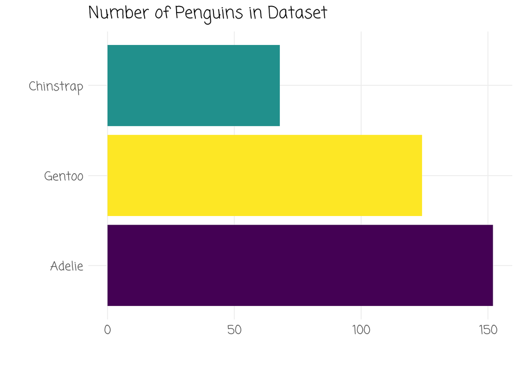

```r
penguins |>
  ggplot(aes(species |> fct_infreq(), fill = species)) +
  geom_bar(show.legend = F) +
  scale_fill_viridis_d() +
  labs(x = "", y = "",
       title = "Number of Penguins in Dataset") +
  coord_flip() +
  theme_clean()
```

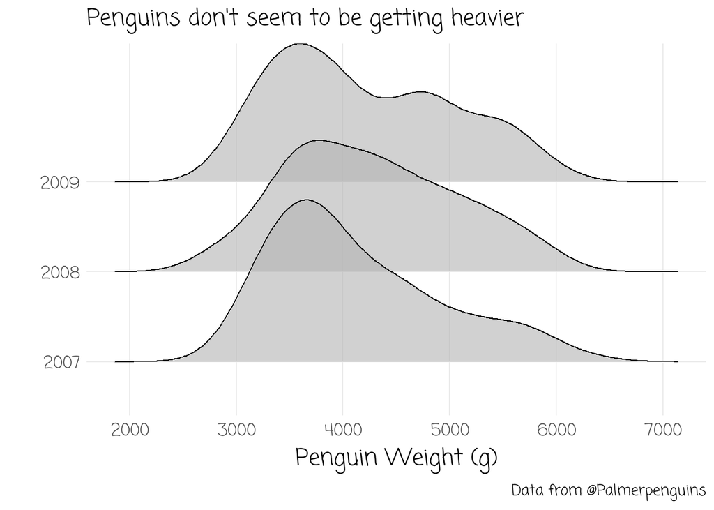

```r
penguins |>
  ggplot(aes(x = body_mass_g, y = as.factor(year))) +
  ggridges::geom_density_ridges(alpha = 0.6) +
  labs(title = "Penguins don't seem to be getting heavier",
       y = "",
       x = "Penguin Weight (g)",
       caption = "Data from @Palmerpenguins") +
  theme_clean()
```

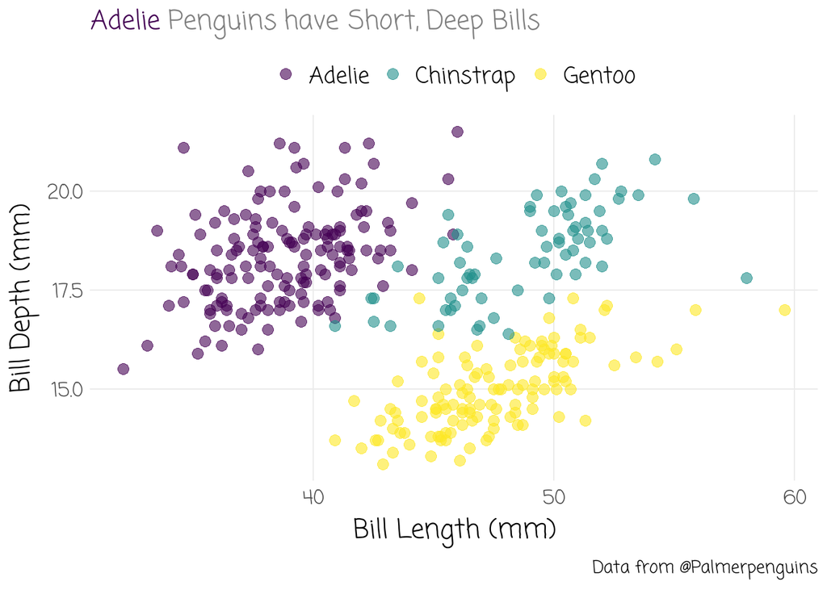

```r
penguins |>
  ggplot(aes(x = bill_length_mm, y = bill_depth_mm, colour = species)) +
  geom_point(size = 3, alpha= 0.6) +
  labs(title = "<span style = 'color:#440154;'>Adelie</span> Penguins have Short, Deep Bills",
       x = "Bill Length (mm)",
       y = "Bill Depth (mm)",
       caption = "Data from @Palmerpenguins") +
  scale_color_viridis_d() +
  theme_clean() +
  theme(legend.position = "top", legend.title=element_blank(),
        legend.text = element_text(size=28), plot.title = ggtext::element_markdown(color="gray50"))
```